# 10 t-tests

Before you run any tests it’s worth plotting your data.

Assuming you have a continuous outcome and categorical (binary) predictor (here we use a subset of the built in `chickwts` data), a boxplot can work well:

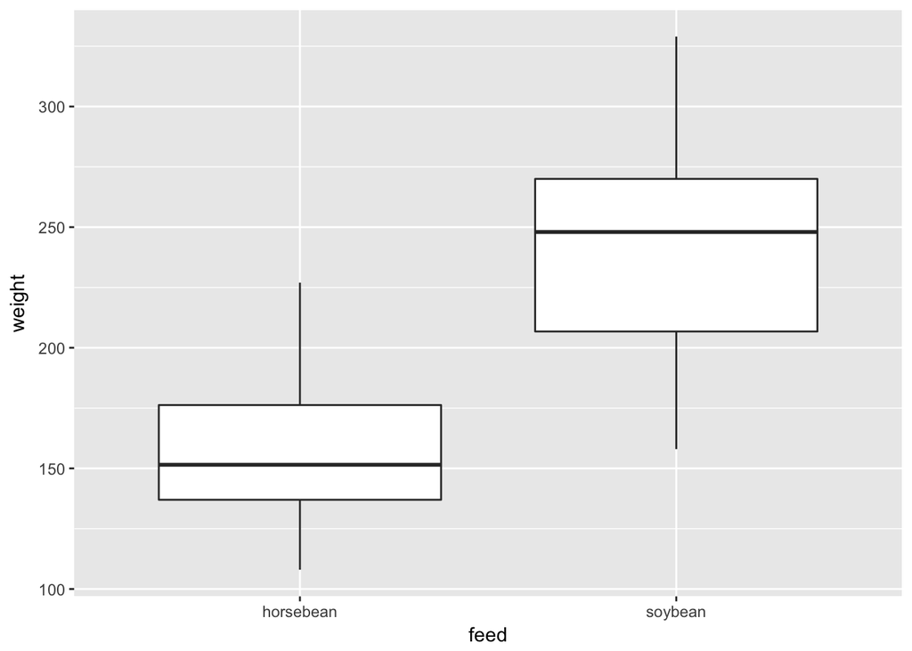

Figure 10.1: The box in a boxplot indictes the IQR; the whisker indicates the min/max values or 1.5 * the IQR, whichever is the smaller. If there are outliers beyond 1.5 * the IQR then they are shown as points.

```r
chicks.eating.beans <- chickwts %>%
  filter(feed %in% c("horsebean", "soybean"))

chicks.eating.beans %>%
  ggplot(aes(feed, weight)) +
  geom_boxplot()
```

Or a violin or bottle plot, which shows the distributions within each group:

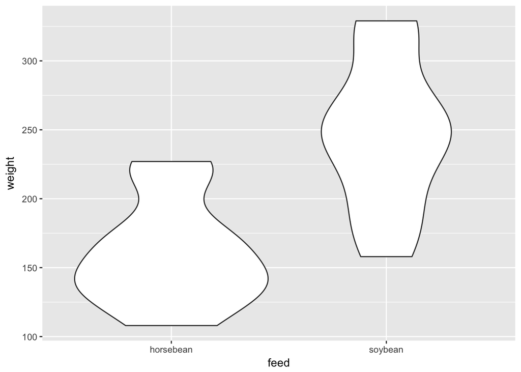

```r
chicks.eating.beans %>%
  ggplot(aes(feed, weight)) +
  geom_violin()
```

Layering boxes and bottles can work well too because it combines information about the distribution with key statistics like the median and IQR, and also because it scales reasonably well to multiple categories:

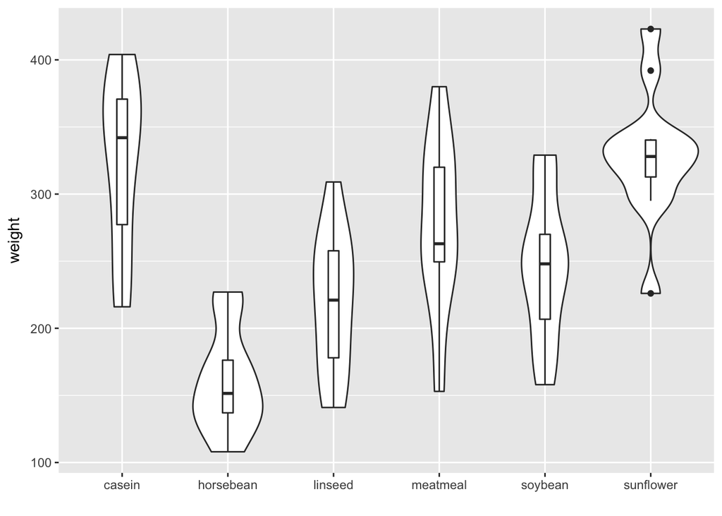

```r
chickwts %>%
  ggplot(aes(feed, weight)) +
  geom_violin() +
  geom_boxplot(width=.1) +
  xlab("")
```

Bottleplots are just density plots, turned 90 degrees. Density plots might be more familiar to some, but it’s hard to show more than 2 or 3 categories:

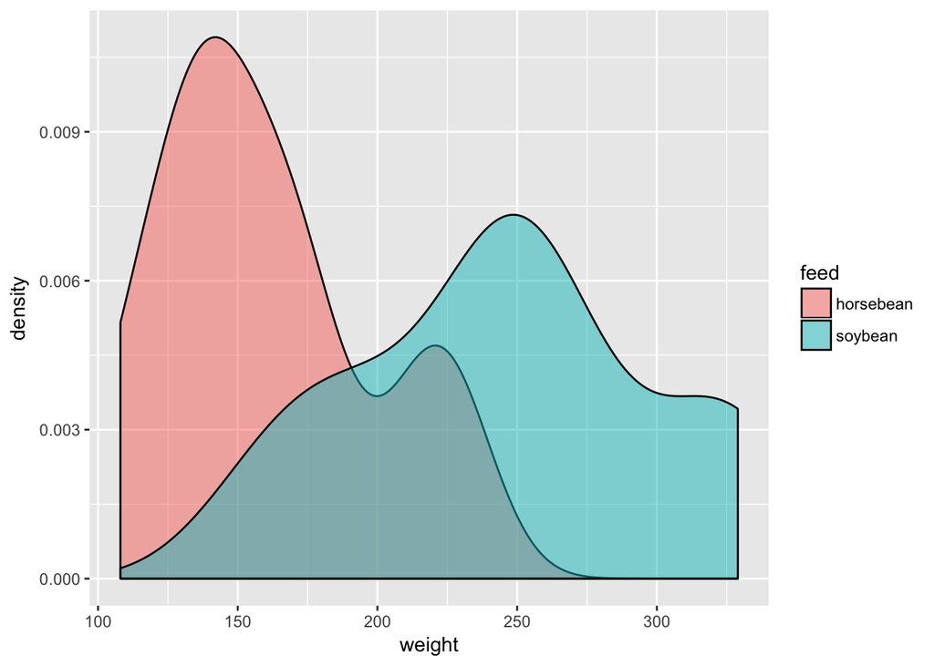

```r
chicks.eating.beans %>%
  ggplot(aes(weight, fill=feed)) +
  geom_density(alpha=.5)
```

And density plots are just smoothed histograms (which you might prefer if you’re a fan of 80’s computer games):

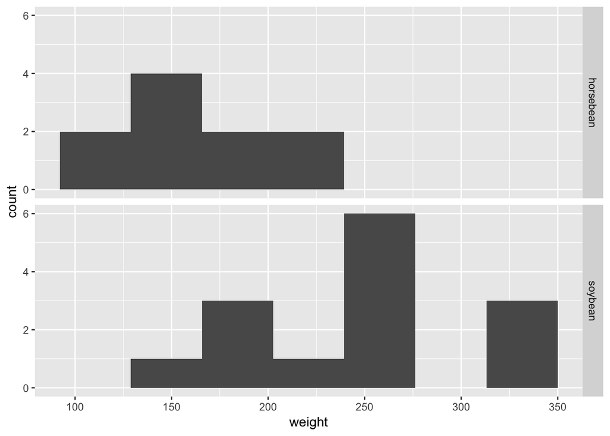

```r
chicks.eating.beans %>%
  ggplot(aes(weight)) +
  geom_histogram(bins=7) +
  facet_grid(feed ~ .)
```

## 10.1 Running t-tests

Assuming you really do still want to run a null hypothesis test, the `t.test()` function performs most common variants:

### 10.1.1 2 independent groups:

```r
with(chicks.eating.beans, t.test(weight ~ feed))
```

```
##
##  Welch Two Sample t-test
##
## data:  weight by feed
## t = -4.5543, df = 21.995, p-value = 0.0001559
## alternative hypothesis: true difference in means is not equal to 0
## 95 percent confidence interval:
##  -125.49476  -46.96238
## sample estimates:
## mean in group horsebean   mean in group soybean
##                160.2000                246.4286
```

Or equivalently, if your data are untidy and each group has it’s own column:

```r
untidy.chicks <- chicks.eating.beans %>%
  mutate(chick = row_number()) %>%
  reshape2::dcast(chick~feed, value.var = 'weight')

with(untidy.chicks, t.test(horsebean, soybean))
```

[output not shown]

### 10.1.2 Unequal variances

By default R assumes your groups have unequal variances and applies an appropriate correction. If you don’t want this you can add `var.equal = TRUE` and get a vanilla t-test:

```r
with(untidy.chicks, t.test(horsebean, soybean, var.equal=TRUE))
```

[output not shown]

### 10.1.3 Paired samples

```r
a <- rnorm(50, 2.5, 1)
b = a + rnorm(50, .5, 1)
t.test(a, b, paired=TRUE)
```

[output not shown]

### 10.1.4 One-sample test

i.e. comparing sample mean with a specific value:

```r
# test if mean of `outcome` variable is different from 2
somedata <- rnorm(50, 2.5, 1)
t.test(somedata, mu=2)
```

[output not shown]